# Description

## Background & Context

The Policy Maker of the company "Visit with us" wants to enable and establish a viable business model to expand the customer base.

A viable business model is a central concept that helps you to understand the existing ways of doing the business and how to change the ways for the benefit of the tourism sector. One of the ways to expand the customer base is to introduce a new offering of packages.

Currently, there are 5 types of packages the company is offering - Basic, Standard, Deluxe, Super Deluxe, King. Looking at the data of the last year, we observed that 18% of the customers purchased the packages. However, the marketing cost was quite high because customers were contacted at random without looking at the available information.

The company is now planning to launch a new product i.e. Wellness Tourism Package. Wellness Tourism is defined as Travel that allows the traveler to maintain, enhance or kick-start a healthy lifestyle, and support or increase one's sense of well-being.

However, this time company wants to harness the available data of existing and potential customers to make the marketing expenditure more efficient. You as a Data Scientist at "Visit with us" travel company have to analyze the customers' data and information to provide recommendations to the Policy Maker and Marketing Team and also build a model to predict the potential customer who is going to purchase the newly introduced travel package.

## Objective

To predict which customer is more likely to purchase the newly introduced travel package

## Data Dictionary

Customer details:

- CustomerID: Unique customer ID
- ProdTaken: Whether the customer has purchased a package or not (0:No, 1: Yes)
- Age: Age of customer
- TypeofContact: How customer was contacted (Company Invited or Self Inquiry)
- CityTier: City tier depends on the development of a city, population, facilities, and living standards. The categories are ordered i.e. Tier 1 > Tier 2 > Tier 3
- Occupation: Occupation of customer
- Gender: Gender of customer
- NumberOfPersonVisiting: Total number of persons planning to take the trip with the customer
- PreferredPropertyStar: Preferred hotel property rating by customer
- MaritalStatus: Marital status of customer
- NumberOfTrips: Average number of trips in a year by customer
- Passport: The customer has a passport or not (0: No, 1: Yes)
- OwnCar: Whether the customers own a car or not (0: No, 1: Yes)
- NumberOfChildrenVisiting: Total number of children with age less than 5
- planning to take the trip with the customer
- Designation: Designation of the customer in the current organization
- MonthlyIncome: Gross monthly income of the customer

### Customer interaction data:

- PitchSatisfactionScore: Sales pitch satisfaction score
- ProductPitched: Product pitched by the salesperson
- NumberOfFollowups: Total number of follow-ups has been done by the salesperson after the sales pitch
- DurationOfPitch: Duration of the pitch by a salesperson to the customer

```python
# this will help in making the Python code more structured automatically.
#!pip install nb-black
%load_ext nb_black
```

```
The nb_black extension is already loaded. To reload it, use:
  %reload_ext nb_black
```

### Loading necessary libraries

```python
import pandas as pd
import numpy as np
import matplotlib.pyplot as plt
import seaborn as sns

sns.set()

import warnings

warnings.filterwarnings("ignore")

# Removes the limit for the number of displayed columns
pd.set_option("display.max_columns", None)
# Sets the limit for the number of displayed rows
pd.set_option("display.max_rows", 200)


# Library to split data
from sklearn.model_selection import train_test_split

# Libraries to import decision tree classifier and different ensemble classifiers
from sklearn.ensemble import BaggingClassifier
from sklearn.ensemble import RandomForestClassifier
from sklearn.tree import DecisionTreeClassifier
from sklearn.linear_model import LogisticRegression
from sklearn import tree

# Libtune to tune model, get different metric scores
from sklearn import metrics
from sklearn.metrics import (
    confusion_matrix,
    classification_report,
    accuracy_score,
    precision_score,
    recall_score,
)
from sklearn.model_selection import GridSearchCV

from sklearn.ensemble import AdaBoostClassifier, GradientBoostingClassifier

# To install xgboost library use - !pip install xgboost
from xgboost import XGBClassifier
from sklearn.ensemble import StackingClassifier

from sklearn.compose import ColumnTransformer
from sklearn.preprocessing import OneHotEncoder
```

### Load the dataset

```python
data = pd.read_excel("Tourism.xlsx", sheet_name="Tourism")

# creating a copy of the data so that original data remains unchanged
df = data.copy()
```

### Sample of the dataset.

```python
print(f"There are {df.shape[0]} rows and {df.shape[1]} columns.")  # f-string

# Sampling 20 random rows
# Random seed via np.random.seed is set so that
# same random results are displayed every time
np.random.seed(1)
df.sample(n=20)
```

```
There are 4888 rows and 20 columns.
```

|  | CustomerID | ProdTaken | Age | TypeofContact | CityTier | DurationOfPitch | Occupation | Gender | NumberOfPersonVisiting | NumberOfFollowups | ProductPitched | PreferredPropertyStar | MaritalStatus | NumberOfTrips | Passport | PitchSatisfactionScore | OwnCar | NumberOfChildrenVisiting | Designation | MonthlyIncome |
| --- | --- | --- | --- | --- | --- | --- | --- | --- | --- | --- | --- | --- | --- | --- | --- | --- | --- | --- | --- | --- |
| 3015 | 203015 | 0 | 27.0 | Company Invited | 1 | 7.0 | Salaried | Female | 4 | 6.0 | Basic | 3.0 | Married | 5.0 | 0 | 4 | 1 | 3.0 | Executive | 23042.0 |
| 1242 | 201242 | 0 | 40.0 | Self Enquiry | 3 | 13.0 | Small Business | Male | 2 | 3.0 | King | 4.0 | Single | 2.0 | 0 | 4 | 1 | NaN | VP | 34833.0 |
| 3073 | 203073 | 0 | 29.0 | Self Enquiry | 2 | 15.0 | Small Business | Male | 4 | 5.0 | Basic | 3.0 | Married | 3.0 | 0 | 2 | 0 | 2.0 | Executive | 23614.0 |
| 804 | 200804 | 0 | 48.0 | Company Invited | 1 | 6.0 | Small Business | Male | 2 | 1.0 | Super Deluxe | 3.0 | Single | 3.0 | 0 | 2 | 0 | 0.0 | AVP | 31885.0 |
| 3339 | 203339 | 0 | 32.0 | Self Enquiry | 1 | 18.0 | Small Business | Male | 4 | 4.0 | Deluxe | 5.0 | Divorced | 3.0 | 1 | 2 | 0 | 3.0 | Manager | 25511.0 |
| 3080 | 203080 | 1 | 36.0 | Company Invited | 1 | 32.0 | Salaried | Female | 4 | 4.0 | Basic | 4.0 | Married | 3.0 | 1 | 3 | 0 | 1.0 | Executive | 20700.0 |
| 2851 | 202851 | 0 | 46.0 | Self Enquiry | 1 | 17.0 | Salaried | Male | 4 | 4.0 | Basic | 3.0 | Divorced | 5.0 | 0 | 5 | 1 | 1.0 | Executive | 21332.0 |
| 2883 | 202883 | 1 | 32.0 | Company Invited | 1 | 27.0 | Salaried | Male | 4 | 4.0 | Standard | 3.0 | Divorced | 5.0 | 0 | 3 | 1 | 1.0 | Senior Manager | 28502.0 |
| 1676 | 201676 | 0 | 22.0 | Self Enquiry | 1 | 11.0 | Salaried | Male | 2 | 1.0 | Basic | 4.0 | Married | 2.0 | 1 | 4 | 1 | 0.0 | Executive | 17328.0 |
| 1140 | 201140 | 0 | 44.0 | Self Enquiry | 1 | 13.0 | Small Business | Female | 2 | 3.0 | King | 3.0 | Married | 1.0 | 1 | 4 | 1 | 1.0 | VP | 34049.0 |
| 748 | 200748 | 1 | 26.0 | Company Invited | 3 | 35.0 | Small Business | Male | 3 | NaN | Deluxe | 5.0 | Single | 1.0 | 0 | 3 | 0 | 0.0 | Manager | 19969.0 |
| 2394 | 202394 | 1 | NaN | Company Invited | 1 | 8.0 | Salaried | Female | 2 | 4.0 | Basic | 5.0 | Single | 3.0 | 1 | 3 | 0 | 0.0 | Executive | 18506.0 |
| 4881 | 204881 | 1 | 41.0 | Self Enquiry | 2 | 25.0 | Salaried | Male | 3 | 2.0 | Basic | 5.0 | Married | 2.0 | 0 | 1 | 1 | 2.0 | Executive | 21065.0 |
| 3415 | 203415 | 0 | 52.0 | Self Enquiry | 1 | 18.0 | Large Business | Female | 3 | 5.0 | Super Deluxe | 4.0 | Single | 5.0 | 0 | 1 | 0 | 2.0 | AVP | 31820.0 |
| 2253 | 202253 | 0 | NaN | Self Enquiry | 1 | 13.0 | Large Business | Female | 2 | 1.0 | Basic | 3.0 | Married | 2.0 | 0 | 3 | 0 | 0.0 | Executive | 18376.0 |
| 3685 | 203685 | 0 | 33.0 | Self Enquiry | 3 | 26.0 | Salaried | Male | 4 | 6.0 | Standard | 3.0 | Married | 5.0 | 0 | 3 | 1 | 3.0 | Senior Manager | 28288.0 |
| 2722 | 202722 | 0 | 27.0 | Company Invited | 1 | 7.0 | Salaried | Female | 3 | 4.0 | Deluxe | 4.0 | Married | 3.0 | 0 | 5 | 0 | 2.0 | Manager | 25075.0 |
| 2886 | 202886 | 0 | 37.0 | Company Invited | 3 | 17.0 | Small Business | Male | 3 | 4.0 | Standard | 3.0 | Single | 3.0 | 0 | 2 | 1 | 2.0 | Senior Manager | 28658.0 |
| 4449 | 204449 | 0 | 42.0 | Self Enquiry | 2 | 17.0 | Salaried | Male | 4 | 5.0 | King | 3.0 | Married | NaN | 0 | 1 | 1 | 2.0 | VP | 37819.0 |
| 1550 | 201550 | 0 | 30.0 | Self Enquiry | 1 | 6.0 | Salaried | Male | 2 | 4.0 | Deluxe | 3.0 | Married | 2.0 | 1 | 1 | 1 | 1.0 | Manager | 20126.0 |

#### Observation:

- Customer id is an identifier column with no real significance to model prediction.
- There are some null values "NaN" in the data set.

### Duplicate values in the data

```python
df.duplicated().sum()
```

```
0
```

#### Observation:

- There are no duplicate rows in the data set.

### List of columns in the data.

### List of column data types in the dataset.

```python
df.info()
```

```
<class 'pandas.core.frame.DataFrame'>
RangeIndex: 4888 entries, 0 to 4887
Data columns (total 20 columns):
 #   Column                    Non-Null Count  Dtype
---  ------                    --------------  -----
 0   CustomerID                4888 non-null   int64
 1   ProdTaken                 4888 non-null   int64
 2   Age                       4662 non-null   float64
 3   TypeofContact             4863 non-null   object
 4   CityTier                  4888 non-null   int64
 5   DurationOfPitch           4637 non-null   float64
 6   Occupation                4888 non-null   object
 7   Gender                    4888 non-null   object
 8   NumberOfPersonVisiting    4888 non-null   int64
 9   NumberOfFollowups         4843 non-null   float64
 10  ProductPitched            4888 non-null   object
 11  PreferredPropertyStar     4862 non-null   float64
 12  MaritalStatus             4888 non-null   object
 13  NumberOfTrips             4748 non-null   float64
 14  Passport                  4888 non-null   int64
 15  PitchSatisfactionScore    4888 non-null   int64
 16  OwnCar                    4888 non-null   int64
 17  NumberOfChildrenVisiting  4822 non-null   float64
 18  Designation               4888 non-null   object
 19  MonthlyIncome             4655 non-null   float64
dtypes: float64(7), int64(7), object(6)
memory usage: 763.9+ KB
```

#### Observation:

- There are 4888 rows in the dataset.
- Among 20 columns, 6 columns has string values.

### Missing values in the data.

#### Observation:

```python
def missing_check(df):
    total = (
        df.isnull().sum().sort_values(ascending=False)
    )  # total number of null values
    percent = (df.isnull().sum() / df.isnull().count()).sort_values(
        ascending=False
    )  # percentage of values that are null
    missing_data = pd.concat(
        [total, percent], axis=1, keys=["Total", "Percent"]
    )  # putting the above two together
    return missing_data  # return the dataframe
```

```python
missing_check(df)
```

|  | Total | Percent |
| --- | --- | --- |
| DurationOfPitch | 251 | 0.051350 |
| MonthlyIncome | 233 | 0.047668 |
| Age | 226 | 0.046236 |
| NumberOfTrips | 140 | 0.028642 |
| NumberOfChildrenVisiting | 66 | 0.013502 |
| NumberOfFollowups | 45 | 0.009206 |
| PreferredPropertyStar | 26 | 0.005319 |
| TypeofContact | 25 | 0.005115 |
| Designation | 0 | 0.000000 |
| OwnCar | 0 | 0.000000 |
| PitchSatisfactionScore | 0 | 0.000000 |
| Passport | 0 | 0.000000 |
| CustomerID | 0 | 0.000000 |
| MaritalStatus | 0 | 0.000000 |
| ProdTaken | 0 | 0.000000 |
| NumberOfPersonVisiting | 0 | 0.000000 |
| Gender | 0 | 0.000000 |
| Occupation | 0 | 0.000000 |
| CityTier | 0 | 0.000000 |
| ProductPitched | 0 | 0.000000 |

#### Observation:

- 8 variables has null values.
- Out of 8, majority of the null values are in DurationOfPitch, MonthlyIncome and Age column.

### Summary of the dataset

```python
df.describe(include="all").T
```

|  | count | unique | top | freq | mean | std | min | 25% | 50% | 75% | max |
| --- | --- | --- | --- | --- | --- | --- | --- | --- | --- | --- | --- |
| CustomerID | 4888.0 | NaN | NaN | NaN | 202443.5 | 1411.188388 | 200000.0 | 201221.75 | 202443.5 | 203665.25 | 204887.0 |
| ProdTaken | 4888.0 | NaN | NaN | NaN | 0.188216 | 0.390925 | 0.0 | 0.0 | 0.0 | 0.0 | 1.0 |
| Age | 4662.0 | NaN | NaN | NaN | 37.622265 | 9.316387 | 18.0 | 31.0 | 36.0 | 44.0 | 61.0 |
| TypeofContact | 4863 | 2 | Self Enquiry | 3444 | NaN | NaN | NaN | NaN | NaN | NaN | NaN |
| CityTier | 4888.0 | NaN | NaN | NaN | 1.654255 | 0.916583 | 1.0 | 1.0 | 1.0 | 3.0 | 3.0 |
| DurationOfPitch | 4637.0 | NaN | NaN | NaN | 15.490835 | 8.519643 | 5.0 | 9.0 | 13.0 | 20.0 | 127.0 |
| Occupation | 4888 | 4 | Salaried | 2368 | NaN | NaN | NaN | NaN | NaN | NaN | NaN |
| Gender | 4888 | 3 | Male | 2916 | NaN | NaN | NaN | NaN | NaN | NaN | NaN |
| NumberOfPersonVisiting | 4888.0 | NaN | NaN | NaN | 2.905074 | 0.724891 | 1.0 | 2.0 | 3.0 | 3.0 | 5.0 |
| NumberOfFollowups | 4843.0 | NaN | NaN | NaN | 3.708445 | 1.002509 | 1.0 | 3.0 | 4.0 | 4.0 | 6.0 |
| ProductPitched | 4888 | 5 | Basic | 1842 | NaN | NaN | NaN | NaN | NaN | NaN | NaN |
| PreferredPropertyStar | 4862.0 | NaN | NaN | NaN | 3.581037 | 0.798009 | 3.0 | 3.0 | 3.0 | 4.0 | 5.0 |
| MaritalStatus | 4888 | 4 | Married | 2340 | NaN | NaN | NaN | NaN | NaN | NaN | NaN |
| NumberOfTrips | 4748.0 | NaN | NaN | NaN | 3.236521 | 1.849019 | 1.0 | 2.0 | 3.0 | 4.0 | 22.0 |
| Passport | 4888.0 | NaN | NaN | NaN | 0.290917 | 0.454232 | 0.0 | 0.0 | 0.0 | 1.0 | 1.0 |
| PitchSatisfactionScore | 4888.0 | NaN | NaN | NaN | 3.078151 | 1.365792 | 1.0 | 2.0 | 3.0 | 4.0 | 5.0 |
| OwnCar | 4888.0 | NaN | NaN | NaN | 0.620295 | 0.485363 | 0.0 | 0.0 | 1.0 | 1.0 | 1.0 |
| NumberOfChildrenVisiting | 4822.0 | NaN | NaN | NaN | 1.187267 | 0.857861 | 0.0 | 1.0 | 1.0 | 2.0 | 3.0 |
| Designation | 4888 | 5 | Executive | 1842 | NaN | NaN | NaN | NaN | NaN | NaN | NaN |
| MonthlyIncome | 4655.0 | NaN | NaN | NaN | 23619.853491 | 5380.698361 | 1000.0 | 20346.0 | 22347.0 | 25571.0 | 98678.0 |

## Exploratory Data Analysis on the data.

### Univariate Analysis

```python
# This functions helps to perfom univariate analysis to study column central tendency and dispersion.


def plot_box_hist(column):
    """Boxplot and histogram combined
    feature: 1-d feature array
    """
    fig, (axis_box, axis_hist) = plt.subplots(
        nrows=2,
        sharex=True,
        gridspec_kw={"height_ratios": (0.3, 0.7)},
        figsize=(15, 5),
    )
    sns.boxplot(column, ax=axis_box, showmeans=True, color="violet")
    sns.distplot(column, ax=axis_hist, kde=True)
    # Add mean to the histogram
    axis_hist.axvline(np.mean(column), color="green", linestyle="--")
    # Add median to the histogram
    axis_hist.axvline(np.median(column), color="red", linestyle="-")
    plt.show()


# This function helps to identify outlier for a given column.
# For this analysis any data points above 4 times of IQR is considers as ooutliers.


def IQR4(column, cname):
    """Gives list that is greater than
    4 times inter quartile range.
    """
    quartiles = np.quantile(column[column.notnull()], [0.25, 0.75])
    power_4iqr = 4 * (quartiles[1] - quartiles[0])
    print(f"Q1 = {quartiles[0]}, Q3 = {quartiles[1]}, 4*IQR = {power_4iqr}")
    outlier_powers = df.loc[np.abs(column - column.median()) > power_4iqr, cname]
    return outlier_powers
```

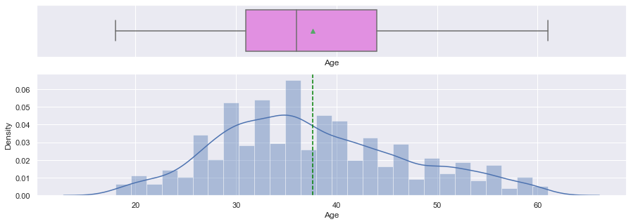

```
Q1 = 31.0, Q3 = 44.0, 4*IQR = 52.0
Series([], Name: Age, dtype: float64)
```

```python
plot_box_hist(df["Age"])

print(IQR4(df["Age"], "Age"))
```

#### Observation:

- Age is distributed almost evenly with slightly right skewed.

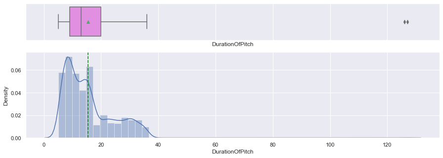

```
Q1 = 9.0, Q3 = 20.0, 4*IQR = 44.0
1434    126.0
3878    127.0
Name: DurationOfPitch, dtype: float64
```

```python
plot_box_hist(df["DurationOfPitch"])

print(IQR4(df["DurationOfPitch"], "DurationOfPitch"))
```

#### Observation:

- Most of the sales pitch is under 15 minutes, however there are few outliers that are over 2 hours.

#### Observation:

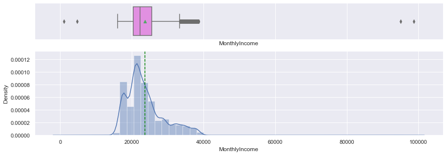

```
Q1 = 20346.0, Q3 = 25571.0, 4*IQR = 20900.0
38      95000.0
142      1000.0
2482    98678.0
Name: MonthlyIncome, dtype: float64
```

```python
plot_box_hist(df["MonthlyIncome"])

print(IQR4(df["MonthlyIncome"], "MonthlyIncome"))
```

#### Observation:

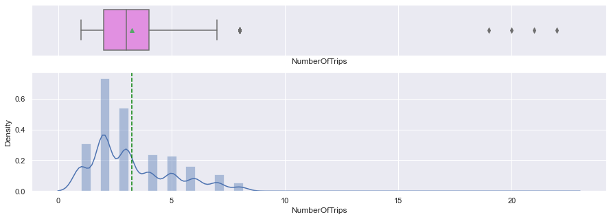

```
Q1 = 2.0, Q3 = 4.0, 4*IQR = 8.0
385     19.0
816     21.0
2829    20.0
3260    22.0
Name: NumberOfTrips, dtype: float64
```

```python
plot_box_hist(df["NumberOfTrips"])

print(IQR4(df["NumberOfTrips"], "NumberOfTrips"))
```

#### Observation:

```python
# Function to create barplots that indicate percentage for each category.


def perc_on_bar(data, column):
    """
    plot
    feature: categorical feature
    the function won't work if a column is passed in hue parameter
    """

    total = len(data[column])  # length of the column
    plt.figure(figsize=(15, 5))
    plt.xticks(rotation=45)
    ax = sns.countplot(data[column], palette="Paired")
    for p in ax.patches:
        percentage = "{:.1f}%".format(
            100 * p.get_height() / total
        )  # percentage of each class of the category
        x = p.get_x() + p.get_width() / 2 - 0.05  # width of the plot
        y = p.get_y() + p.get_height()  # hieght of the plot

        ax.annotate(percentage, (x, y), size=10)  # annotate the percantage
    plt.show()  # show the plot
```

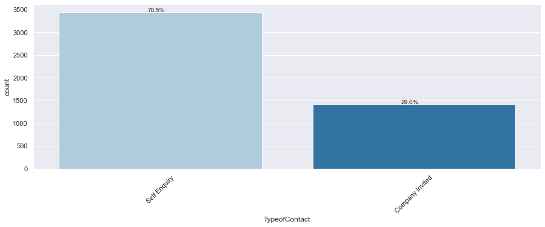

```python
perc_on_bar(df, "TypeofContact")
```

#### Observation:

- Around 70% of the customers inquired on their own about the travel package. (Word of mouth)

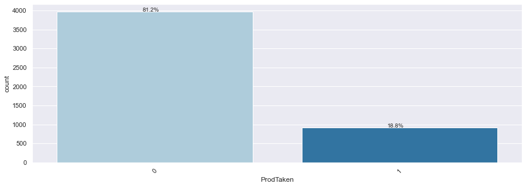

```python
perc_on_bar(df, "ProdTaken")
```

#### Observation:

- Around 20% of the customers actually brought package.
- Data is heavily skewed towards customers who haven't purchased package.
- ProdTaken is the target variable.

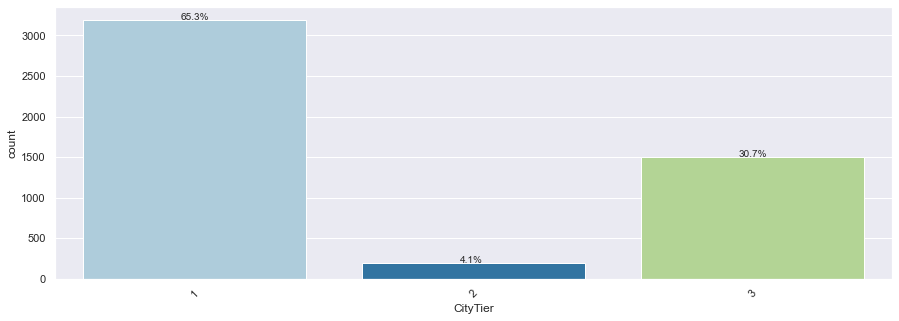

```python
perc_on_bar(df, "CityTier")
```

#### Observation:

- Most of the customers live in Tier 1 cities

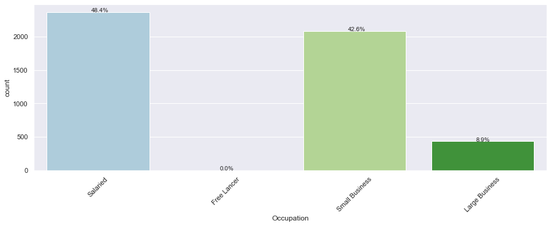

```python
perc_on_bar(df, "Occupation")
```

#### Observation:

- Majority of the customers are Salaried or small business owners.

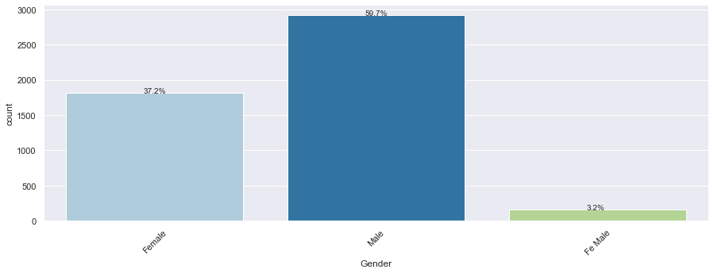

```python
perc_on_bar(df, "Gender")
```

#### Observation:

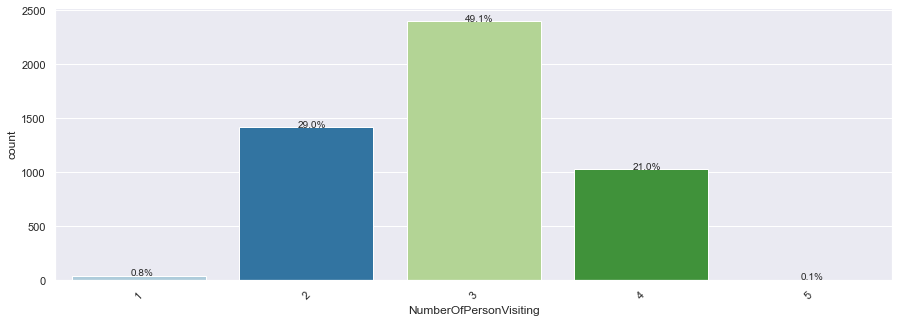

```python
perc_on_bar(df, "NumberOfPersonVisiting")
```

#### Observation:

- Most of the customers accompany with someone while traveling.

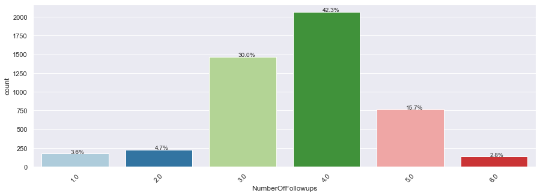

```python
perc_on_bar(df, "NumberOfFollowups")
```

#### Observation:

- Marketing team at-least follow ups 3 or 4 times to get any confirmation (Yes or No)

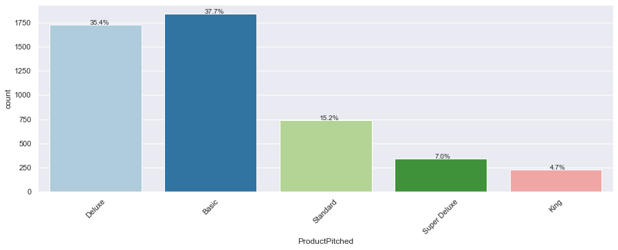

```python
perc_on_bar(df, "ProductPitched")
```

#### Observation:

- Basic and Deluxe package are the popular packages (What marketing team pitches.)

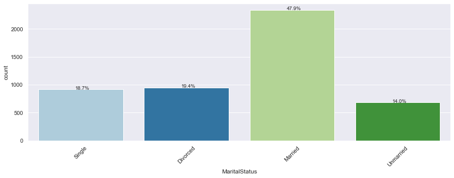

```python
perc_on_bar(df, "MaritalStatus")
```

#### Observation:

- Almost half of the customers are married.

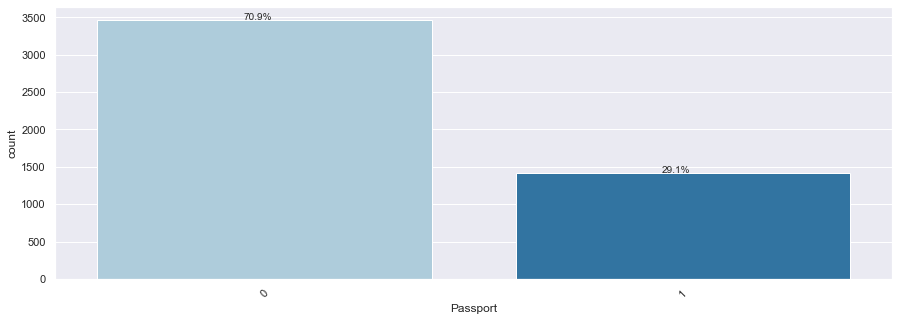

```python
perc_on_bar(df, "Passport")
```

#### Observation:

- Majority of the customer doesn't have passport.

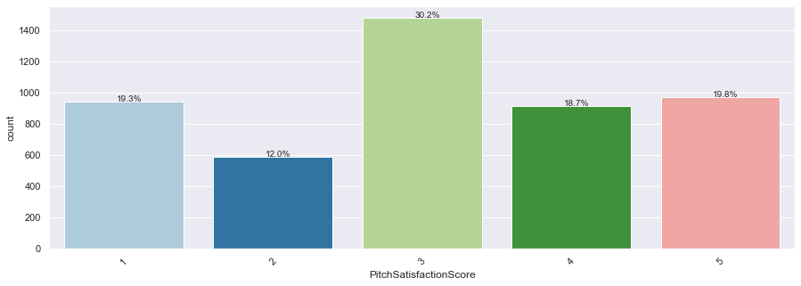

```python
perc_on_bar(df, "PitchSatisfactionScore")
```

#### Observation:

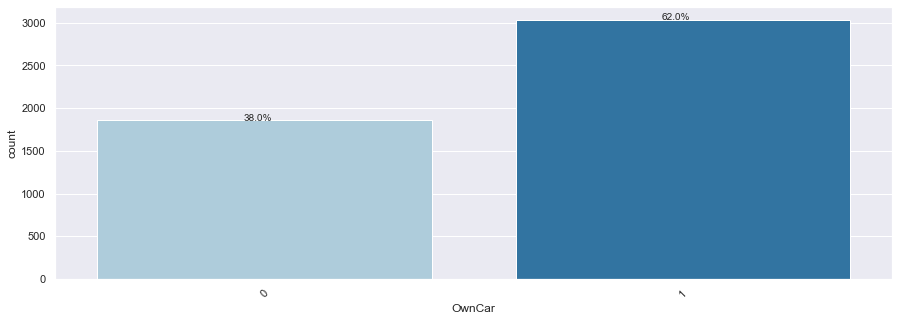

```python
perc_on_bar(df, "OwnCar")
```

#### Observation:

- Majority of the customer own at-least a car.

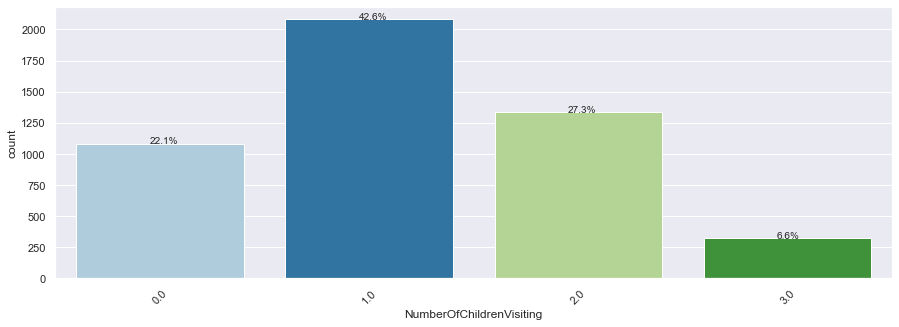

```python
perc_on_bar(df, "NumberOfChildrenVisiting")
```

#### Observation:

- Most of the customers travel with the family (i.e. children)

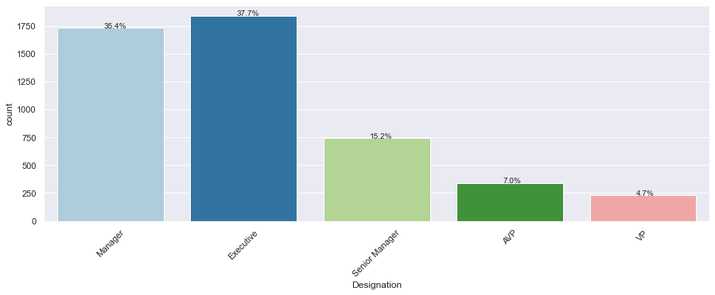

```python
perc_on_bar(df, "Designation")
```

#### Observation:

- Among salaried customers, most of them are manager and executives.

### Bivariate Analysis

```python
# creating a 2-D Matrix with correlation plots
correlation = df.corr()
correlation
```

|  | CustomerID | ProdTaken | Age | CityTier | DurationOfPitch | NumberOfPersonVisiting | NumberOfFollowups | PreferredPropertyStar | NumberOfTrips | Passport | PitchSatisfactionScore | OwnCar | NumberOfChildrenVisiting | MonthlyIncome |
| --- | --- | --- | --- | --- | --- | --- | --- | --- | --- | --- | --- | --- | --- | --- |
| CustomerID | 1.000000 | 0.056506 | 0.032127 | 0.012975 | 0.064298 | 0.604013 | 0.427539 | 0.010553 | 0.224848 | 0.007974 | -0.035847 | 0.003805 | 0.511763 | 0.276833 |
| ProdTaken | 0.056506 | 1.000000 | -0.147254 | 0.086852 | 0.078257 | 0.009627 | 0.112171 | 0.099577 | 0.018898 | 0.260844 | 0.051394 | -0.011508 | 0.007421 | -0.130585 |
| Age | 0.032127 | -0.147254 | 1.000000 | -0.015625 | -0.012063 | 0.011621 | -0.002577 | -0.010474 | 0.184905 | 0.033399 | 0.018510 | 0.048654 | 0.007370 | 0.464869 |
| CityTier | 0.012975 | 0.086852 | -0.015625 | 1.000000 | 0.022703 | -0.001671 | 0.023652 | -0.009164 | -0.029709 | 0.001793 | -0.042160 | 0.003817 | 0.000672 | 0.051817 |
| DurationOfPitch | 0.064298 | 0.078257 | -0.012063 | 0.022703 | 1.000000 | 0.065141 | 0.009434 | -0.006637 | 0.009715 | 0.033034 | -0.002880 | -0.001626 | 0.031408 | -0.006252 |
| NumberOfPersonVisiting | 0.604013 | 0.009627 | 0.011621 | -0.001671 | 0.065141 | 1.000000 | 0.328569 | 0.033867 | 0.195223 | 0.011177 | -0.019581 | 0.010362 | 0.610621 | 0.195134 |
| NumberOfFollowups | 0.427539 | 0.112171 | -0.002577 | 0.023652 | 0.009434 | 0.328569 | 1.000000 | -0.024176 | 0.139517 | 0.004970 | 0.004054 | 0.012112 | 0.286425 | 0.176503 |
| PreferredPropertyStar | 0.010553 | 0.099577 | -0.010474 | -0.009164 | -0.006637 | 0.033867 | -0.024176 | 1.000000 | 0.012115 | 0.001040 | -0.022701 | 0.015742 | 0.035798 | 0.014289 |
| NumberOfTrips | 0.224848 | 0.018898 | 0.184905 | -0.029709 | 0.009715 | 0.195223 | 0.139517 | 0.012115 | 1.000000 | 0.012949 | -0.004378 | -0.011825 | 0.168795 | 0.139105 |
| Passport | 0.007974 | 0.260844 | 0.033399 | 0.001793 | 0.033034 | 0.011177 | 0.004970 | 0.001040 | 0.012949 | 1.000000 | 0.002926 | -0.022330 | 0.020264 | 0.002545 |
| PitchSatisfactionScore | -0.035847 | 0.051394 | 0.018510 | -0.042160 | -0.002880 | -0.019581 | 0.004054 | -0.022701 | -0.004378 | 0.002926 | 1.000000 | 0.068850 | 0.000878 | 0.030421 |
| OwnCar | 0.003805 | -0.011508 | 0.048654 | 0.003817 | -0.001626 | 0.010362 | 0.012112 | 0.015742 | -0.011825 | -0.022330 | 0.068850 | 1.000000 | 0.026572 | 0.080262 |
| NumberOfChildrenVisiting | 0.511763 | 0.007421 | 0.007370 | 0.000672 | 0.031408 | 0.610621 | 0.286425 | 0.035798 | 0.168795 | 0.020264 | 0.000878 | 0.026572 | 1.000000 | 0.201643 |
| MonthlyIncome | 0.276833 | -0.130585 | 0.464869 | 0.051817 | -0.006252 | 0.195134 | 0.176503 | 0.014289 | 0.139105 | 0.002545 | 0.030421 | 0.080262 | 0.201643 | 1.000000 |

#### Observation:

- Age and monthly income has some positive linear relationship, which makes sense.

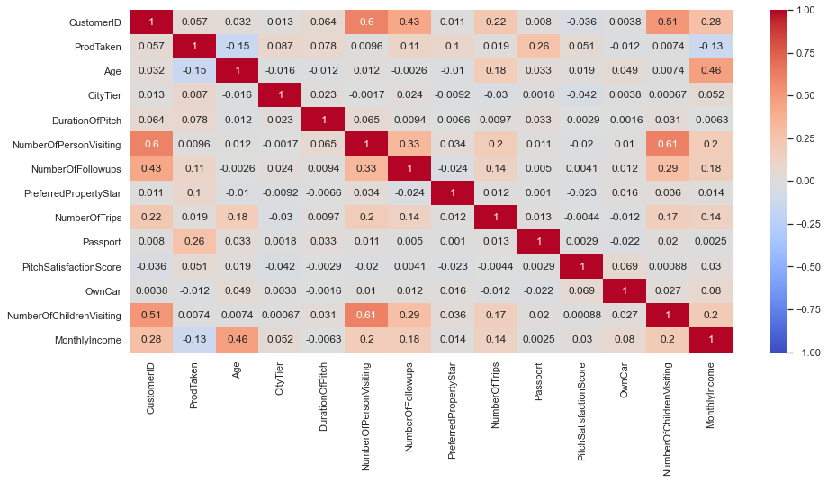

```python
plt.figure(figsize=(15, 7))
sns.heatmap(correlation, annot=True, vmin=-1, vmax=1, cmap="coolwarm")
plt.show()
```

#### Observation:

- Number of person and number of children visiting has strong relationship, This might indicate multicollinearity among these 2 variable.
- Passport has positive relationship with target variable ProductTaken.
- Age and Monthly income has negative relationship with target variable ProductTaken.

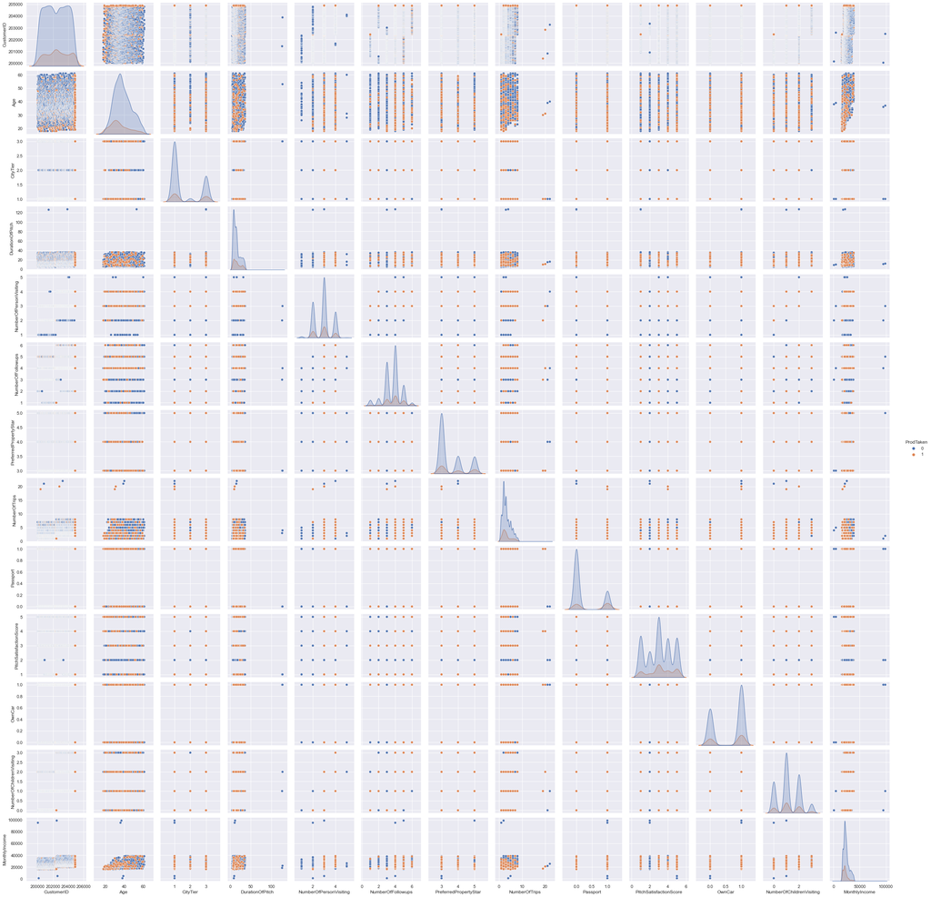

```python
sns.pairplot(df, hue="ProdTaken")
plt.show()
```

#### Observation:

```python
### Function to plot stacked bar charts for categorical columns


def stacked_plot(x):
    sns.set()
    tab1 = pd.crosstab(x, data["ProdTaken"], margins=True)
    print(tab1)
    print("-" * 120)
    tab = pd.crosstab(x, data["ProdTaken"], normalize="index")
    tab.plot(kind="bar", stacked=True, figsize=(10, 5))
    plt.legend(loc="lower left", frameon=False)
    plt.legend(loc="upper left", bbox_to_anchor=(1, 1))
    plt.show()
```

```
ProdTaken           0    1   All
TypeofContact
Company Invited  1109  310  1419
Self Enquiry     2837  607  3444
All              3946  917  4863
------------------------------------------------------------------------------------------------------------------------
```

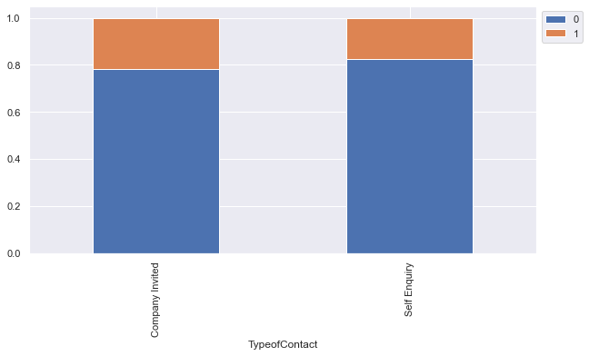

```python
### ProdTaken vs TypeofContact
stacked_plot(data["TypeofContact"])
```

#### Observation:

- There is no strong relationship between type of contact (Company invited and self inquiry) with package purchased.
- However, company invited has sight advantage.

```
ProdTaken     0    1   All
CityTier
1          2670  520  3190
2           152   46   198
3          1146  354  1500
All        3968  920  4888
------------------------------------------------------------------------------------------------------------------------
```

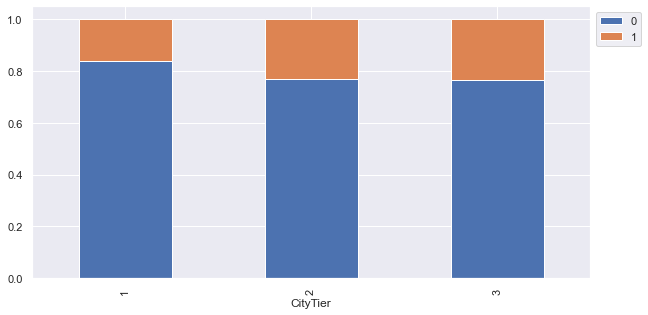

```python
### ProdTaken vs CityTier
stacked_plot(data["CityTier"])
```

#### Observation:

- There is no strong relationship between customer city (Tier 1, Tier 2 and Tier 3) with package purchased.
- Majority of the customers lives in City Tier 1 and however City Tier 2 and 3 customers have made slightly more package purchase (in-terms of percentage.)

```
ProdTaken          0    1   All
Occupation
Free Lancer        0    2     2
Large Business   314  120   434
Salaried        1954  414  2368
Small Business  1700  384  2084
All             3968  920  4888
------------------------------------------------------------------------------------------------------------------------
```

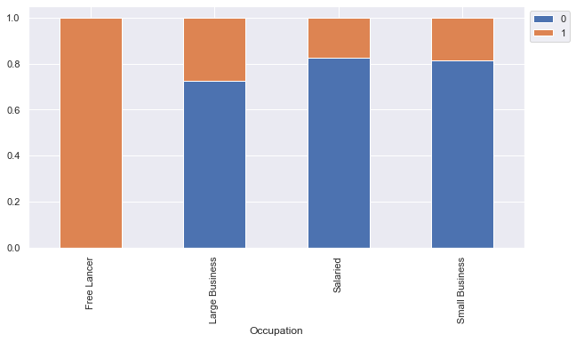

```python
### ProdTaken vs Occupation
stacked_plot(data["Occupation"])
```

#### Observation:

- There are only 2 free lancer customer and both of them brought the package. They can be targeted more in the future.
- Large business customers has more package purchase rate than salaried and small business customers.

```
ProdTaken     0    1   All
Gender
Fe Male     130   25   155
Female     1500  317  1817
Male       2338  578  2916
All        3968  920  4888
------------------------------------------------------------------------------------------------------------------------
```

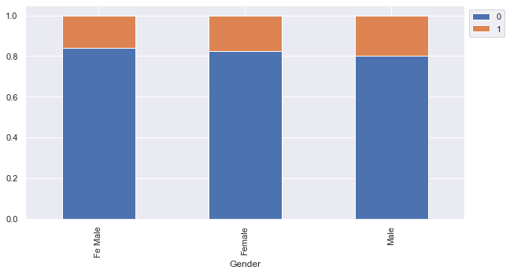

```python
### ProdTaken vs Gender
stacked_plot(data["Gender"])
```

#### Observation:

- Package purchase are evenly distributed among male and female customer.
- Fe Male and female are same gender that needs to be merged.

```
ProdTaken                  0    1   All
NumberOfPersonVisiting
1                         39    0    39
2                       1151  267  1418
3                       1942  460  2402
4                        833  193  1026
5                          3    0     3
All                     3968  920  4888
------------------------------------------------------------------------------------------------------------------------
```

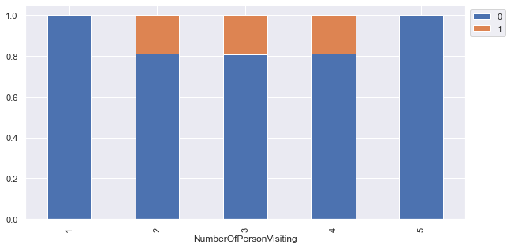

```python
### ProdTaken vs NumberOfPersonVisiting
stacked_plot(data["NumberOfPersonVisiting"])
```

#### Observation:

- Large family customers don't buy travel package.
- Customers don't like to travel alone.

```
ProdTaken                 0    1   All
PreferredPropertyStar
3.0                    2511  482  2993
4.0                     731  182   913
5.0                     706  250   956
All                    3948  914  4862
------------------------------------------------------------------------------------------------------------------------
```

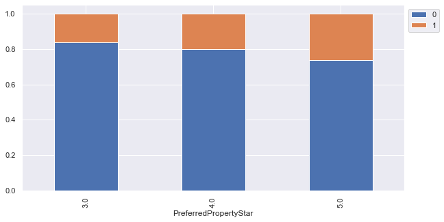

```python
### ProdTaken vs PreferredPropertyStar
stacked_plot(data["PreferredPropertyStar"])
```

#### Observation:

- Customers like to stay at property that has high ratings.

```
ProdTaken         0    1   All
MaritalStatus
Divorced        826  124   950
Married        2014  326  2340
Single          612  304   916
Unmarried       516  166   682
All            3968  920  4888
------------------------------------------------------------------------------------------------------------------------
```

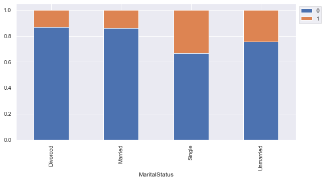

```python
### ProdTaken vs MaritalStatus
stacked_plot(data["MaritalStatus"])
```

#### Observation:

- Single and unmarried customers travel a lot.
- This means many things including friends traveling together, elderly bucket list traveler.

```
ProdTaken     0    1   All
Passport
0          3040  426  3466
1           928  494  1422
All        3968  920  4888
------------------------------------------------------------------------------------------------------------------------
```

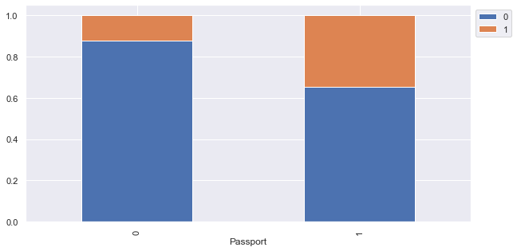

```python
###ProdTaken vs Passport
stacked_plot(data["Passport"])
```

#### Observation:

- Customers with passport travel a lot.
- This may indicate overseas travel package.

```
ProdTaken     0    1   All
OwnCar
0          1496  360  1856
1          2472  560  3032
All        3968  920  4888
------------------------------------------------------------------------------------------------------------------------
```

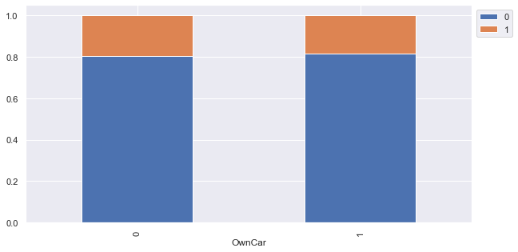

```python
### ProdTaken vs OwnCar
stacked_plot(data["OwnCar"])
```

#### Observation:

- Customer car ownership is not relevant to travel package purchase

```
ProdTaken                    0    1   All
NumberOfChildrenVisiting
0.0                        880  202  1082
1.0                       1688  392  2080
2.0                       1082  253  1335
3.0                        259   66   325
All                       3909  913  4822
------------------------------------------------------------------------------------------------------------------------
```

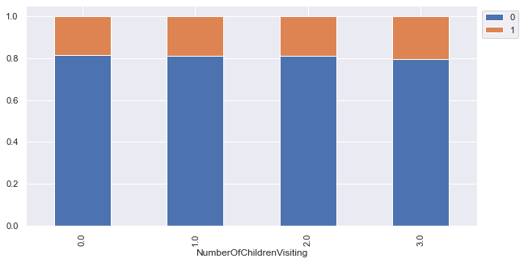

```python
### ProdTaken vs NumberOfChildrenVisiting
stacked_plot(data["NumberOfChildrenVisiting"])
```